# HDP USA

**Dáta v súbore gnpUSA.txt predstavujú časový rad zachytávajúci rast HDP v Spojených štátoch amerických štvrťročne v období druhý kvartál 1947 do prvého kvartálu 1991. (gross national product)**

**Úloha:** Urobte predikciu rastu HDP na zvyšné tri kvartály roku 1991 a zhodnoťte.

#### 1. Zobrazíme časový rad a slovne popíšeme

**Načítanie dát**

```r
gnpUSA <- read.table("gnpUSA.txt", quote="\"", comment.char="")
str(gnpUSA)
```

```
## 'data.frame':    176 obs. of  1 variable:
##  $ V1: num  0.00632 0.00366 0.01202 0.00627 0.01761 ...
```

```r
GNP<-gnpUSA$V1
```

**Zobrazenie dát**

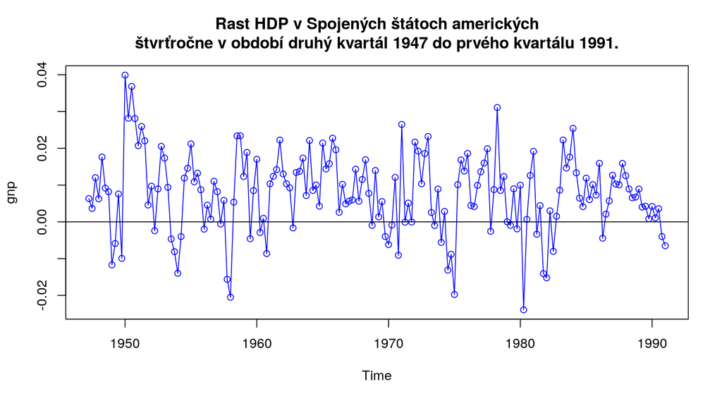

```r
gnp<-ts(GNP, start=c(1947,2),frequency=4)
plot(gnp,type="o",col="blue", main = "Rast HDP v Spojených štátoch amerických
štvrťročne v období druhý kvartál 1947 do prvého kvartálu 1991.")
abline(0,0)
```

**Pozorovanie**

- konštantný nenulový trend
- ustálená variabilita

#### 2. Nájdeme tento trend a odstránime ho, aby sme dostali reziduá.

Ako? Diferencovaním, regresiou. Vyberieme si regresiu.

Ľahko sa dá ukázať, že metódou najmenších štvorcov dostaneme trend rovný priemeru.

```r
c<-mean(gnp)
c
```

```
## [1] 0.00774125
```

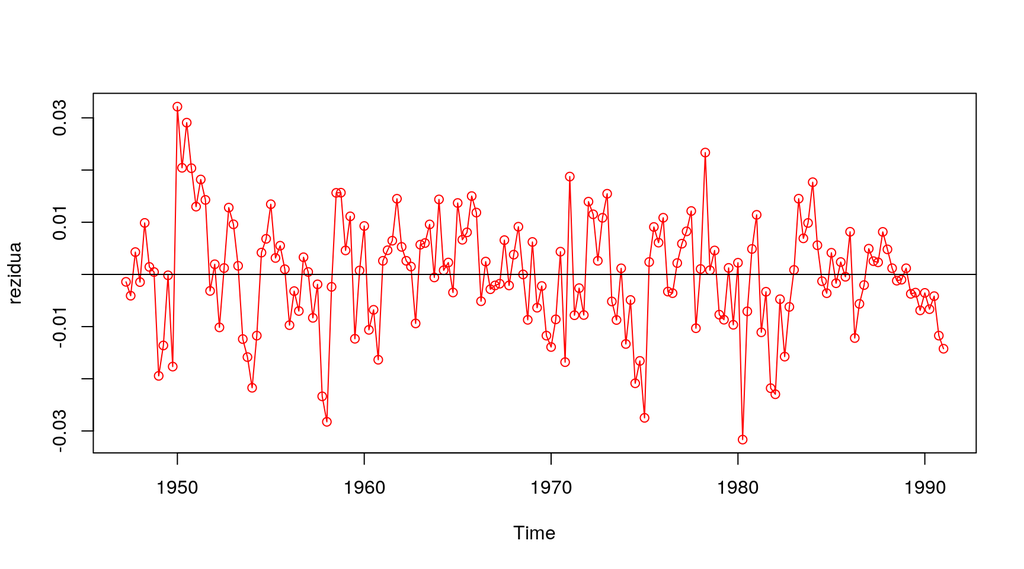

```r
rezidua<-gnp-mean(gnp)
plot(rezidua, type="o",col="red")
abline(0,0)
```

Záver:
$$X(t)=0,0077+Y(t)$$

V prípade konštantného trendu však netreba odstraňovať tento trend v R, pretože príkazy vedia pracovať s touto konštantou. Možno pracovať priamo s pôvodným radom, ktorý je už stacionárny.

#### 3. Hľadanie modelu pre $X(t)$

Využijeme identifikáciu modelu pomocou ACF a PACF

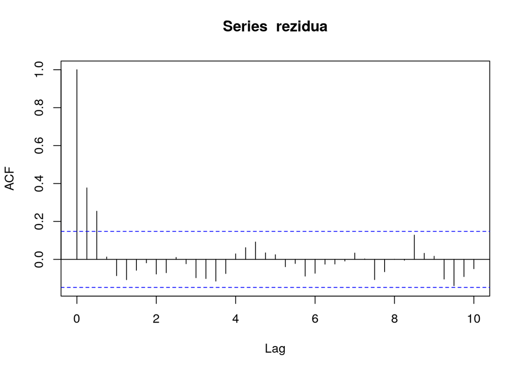

```r
acf(rezidua, 40)
```

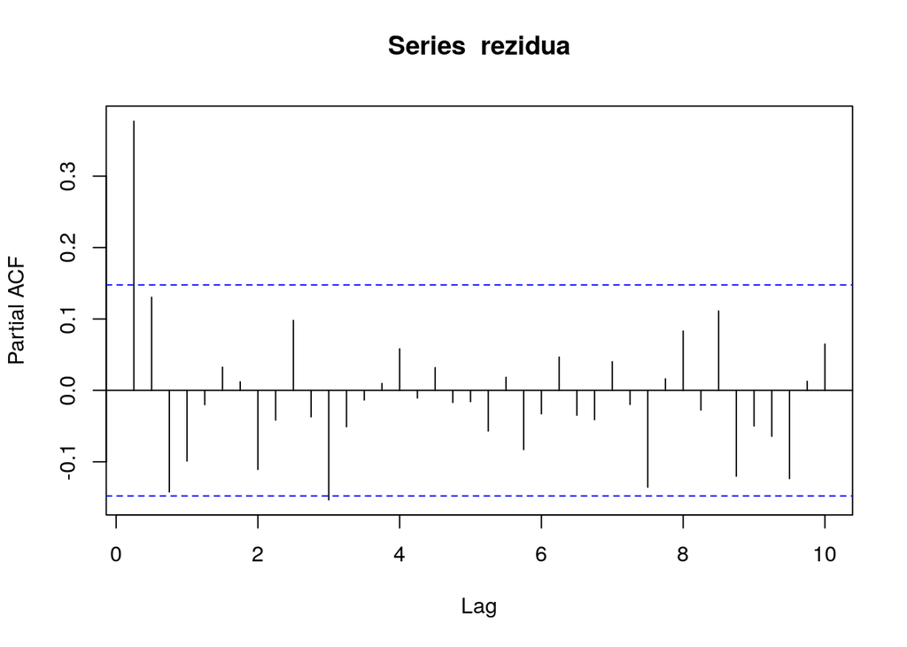

```r
pacf(rezidua, 40)
```

Podľa ACF MA(2) a podľa PACF AR(1) - volíme ten s menším počtom parametrov(princíp úspornosti). Model teda hľadáme v tvare:
$$X(t) - \mu = \phi X(t-1) + Z(t),$$
kde $Z(t) \sim WN(0,\sigma^2)$.

```r
# ar.ols(gnp, order.max = 1) # minule sme pouzili toto - metoda najmensich stvorcov
m1 = ar.mle(gnp, order = 1) # metoda maximalnej vierohodnosti
m1
```

```
##
## Call:
## ar.mle(x = gnp, order.max = 1)
##
## Coefficients:
##      1
## 0.3786
##
## Order selected 1  sigma^2 estimated as  9.801e-05
```

Je toto dostatočné? Mali by sme sa pozrieť na reziduá. Je užitočné používať príkaz names - vypíše všetky premenné uložené v objekte.

```r
names(m1)
```

```
##  [1] "order"        "ar"           "var.pred"     "x.mean"
##  [5] "aic"          "n.used"       "order.max"    "partialacf"
##  [9] "resid"        "method"       "series"       "frequency"
## [13] "call"         "asy.var.coef"
```

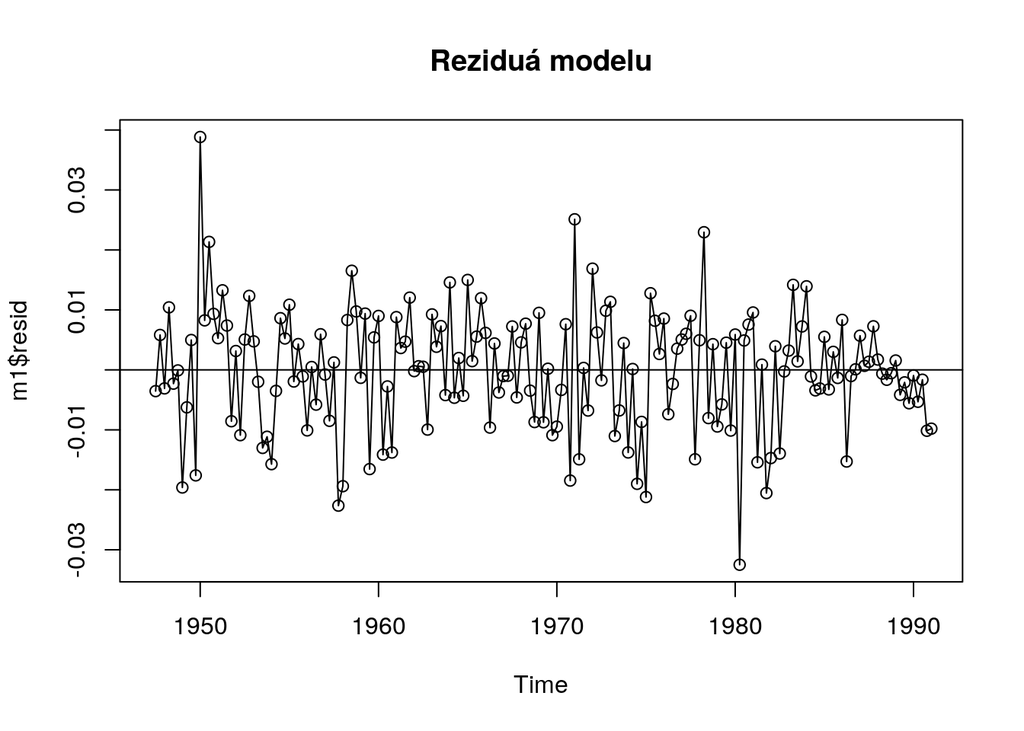

```r
plot(m1$resid, main='Reziduá modelu',type='o')
abline(0,0)
```

Alternatívne možno na modelovanie použiť aj príkaz ARIMA:

```r
m2 = arima(gnp, order=c(1,0,0), method = 'ML')
names(m2)
```

```
##  [1] "coef"      "sigma2"    "var.coef"  "mask"      "loglik"
##  [6] "aic"       "arma"      "residuals" "call"      "series"
## [11] "code"      "n.cond"    "nobs"      "model"
```

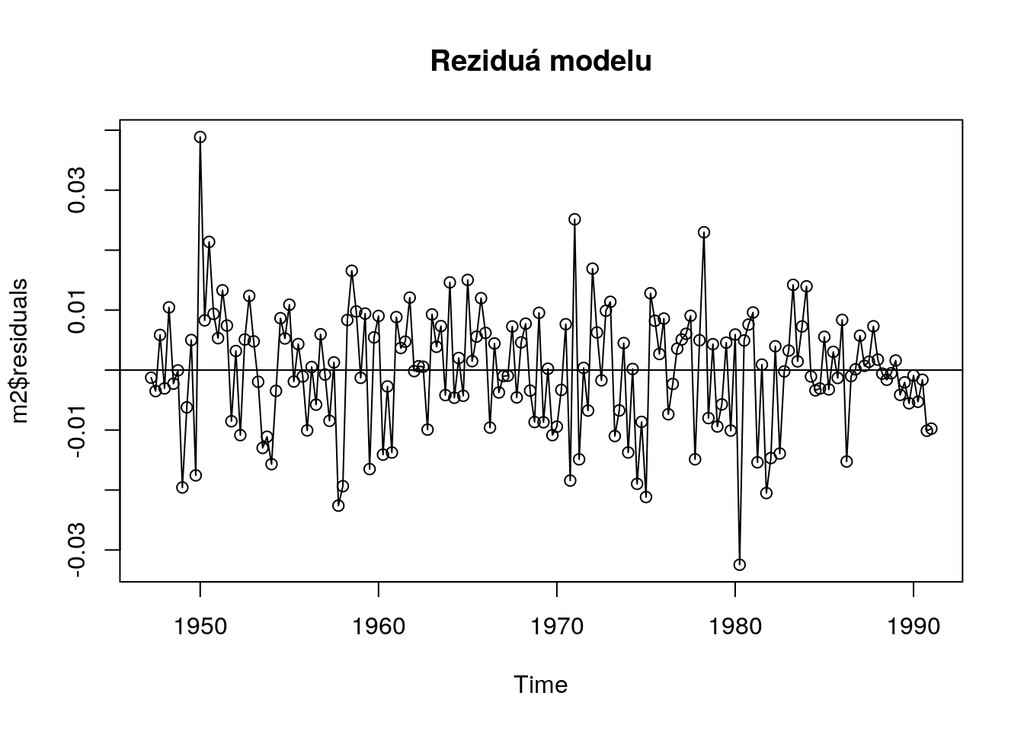

```r
plot(m2$residuals, main='Reziduá modelu',type='o')
abline(0,0)
```

Dostávame rovnaký model. Overme správnosť.

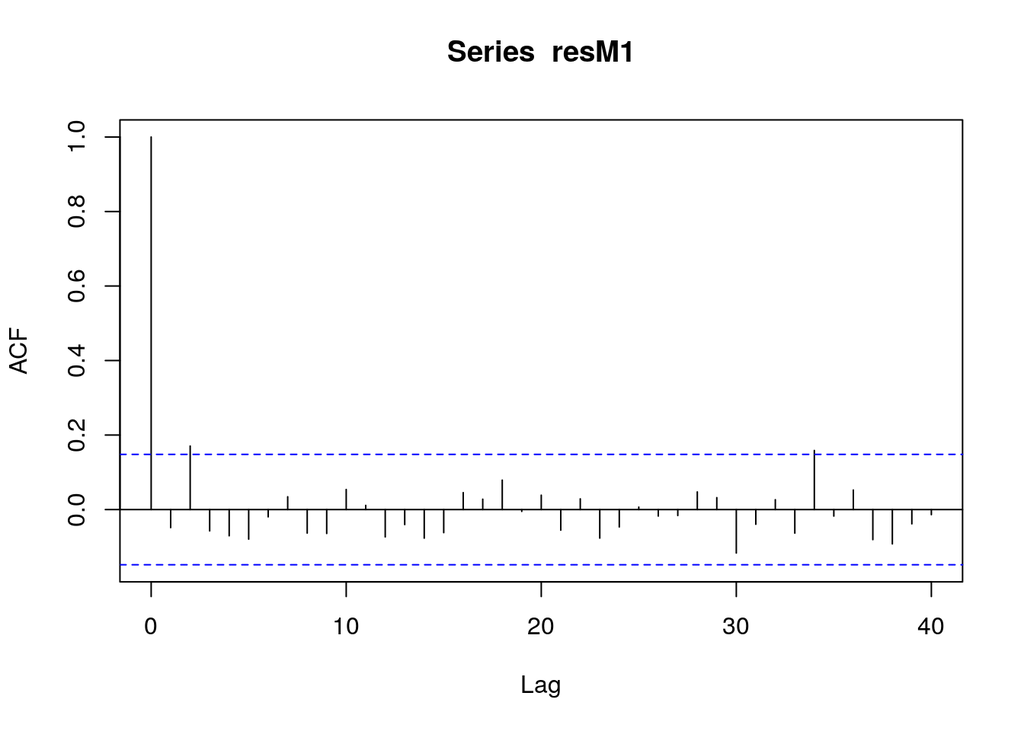

```r
resM1 = m1$resid[2:length(m1$resid)]
acf(resM1,40)
```

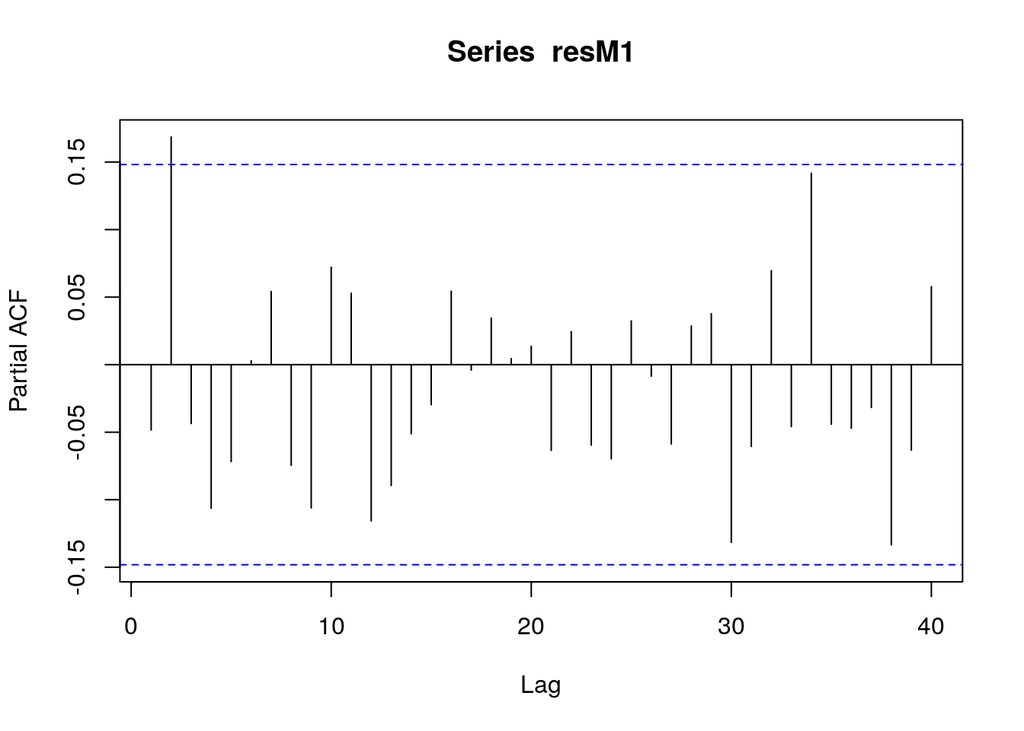

```r
pacf(resM1,40)
```

```r
Box.test(resM1)
```

```
##
##  Box-Pierce test
##
## data:  resM1
## X-squared = 0.41039, df = 1, p-value = 0.5218
```

```r
Box.test(resM1, type='Ljung')
```

```
##
##  Box-Ljung test
##
## data:  resM1
## X-squared = 0.41747, df = 1, p-value = 0.5182
```

#### 4. Odhadneme koeficienty modelu

Ako? Metódy OLS, MLE, Yule-Walker pre AR proces. V R to vie urobiť príkaz ar, resp. arima, keďže ar je špeciálny prípad arima. Vyskúšame metódu mle.

#### 5. Overenie správnosti modelu

#### 6. Predikcia budúcich hodnôt (pre 3 nasledujúce kvartály)

Napr. pomocou BLUP.

```r
m1pred = predict(m1, n.ahead=3)
m1pred
```

```
## $pred
##             Qtr2        Qtr3        Qtr4
## 1991 0.002348909 0.005699257 0.006967756
##
## $se
##             Qtr2        Qtr3        Qtr4
## 1991 0.009899883 0.010585706 0.010680411
```

#### 7. Grafické znázornenie predikcie

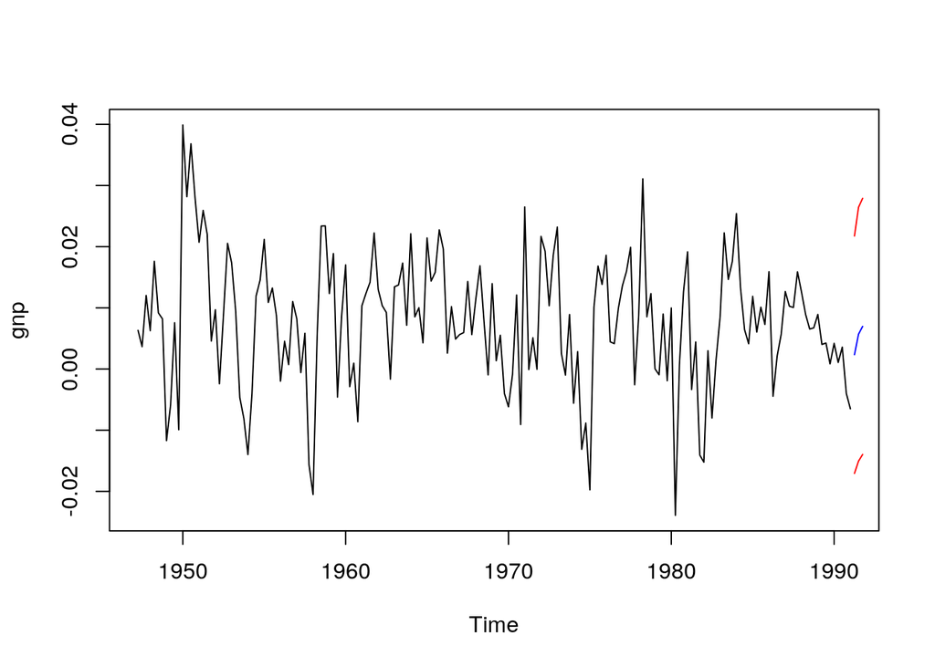

```r
PR = m1pred$pred
CH = m1pred$se

H = PR + 1.96*CH
D = PR - 1.96*CH

h = ts(H, start=c(1991,2), frequency = 4)
d = ts(D, start=c(1991,2), frequency = 4)
pr = ts(PR, start=c(1991,2), frequency = 4)
plot(gnp)
lines(pr, col = 'blue')
lines(h, col = 'red')
lines(d, col = 'red')
```

LEPŠÍ MODEL - IDENTIFIKÁCIA pomocou Akaikeho informačného kritéria (nie pomocou ACF), čo je štatistika istého tvaru, pričom R-excel prejde cez všetky možné AR modely. Riadi sa pri tom jedným z bodov Okhamovej britvy, t.j. vyberie model s najmenším rozptylom bieleho šumu.

#### 3. - 4. Odhalenie modelu a jeho koeficientov

```r
m = ar.mle(gnp) # metoda maximalnej vierohodnosti
m
```

```
##
## Call:
## ar.mle(x = gnp)
##
## Coefficients:
##       1        2        3
##  0.3480   0.1793  -0.1423
##
## Order selected 3  sigma^2 estimated as  9.427e-05
```

Program dáva AR(3), ktorý má o trochu menšiu sigmu.